# 추론통계_경희대

```
    `- 모집단의 특성을 알아내는 과정을 말한다.
    - 예측은 물론, 머신러닝 등을 통해서 나온 분석의 결과가 통계적으로 유의한 지를 검증하는 역할을 한다.`
```

## 1. 가설 설정

- 귀무 가설
- 대립 가설 : 검증하고자 하는 사실.
- 정규 분포: 가설 검증의 기반 !

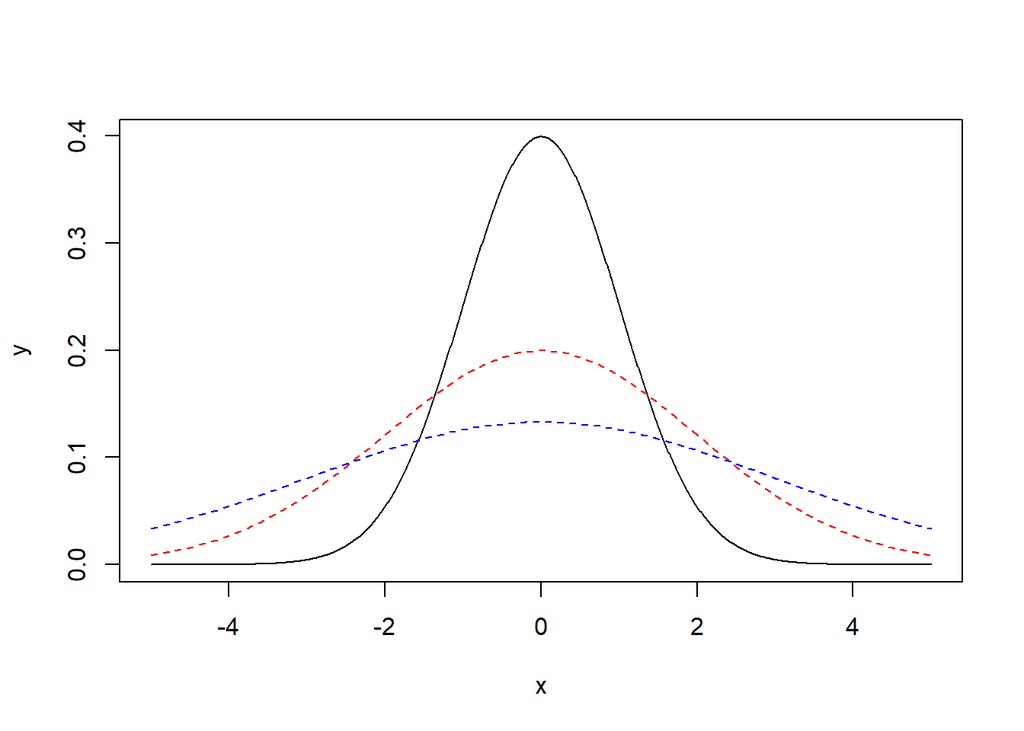

```r
x <- seq(-5,5,length=1000)
y <- dnorm(x, mean =0, sd=1) # y 가 정규분포가 되도록 만들어준다.
plot(x,y, type='l',lwd=1) #평균=0이고 표준편차=1 인게 표준정규분포지.

den.norm <- function(x) dnorm(x, mean=0, sd=2)
curve(den.norm, add=T, col="red",lty=2)

den.norm <- function(x) dnorm(x, mean=0, sd=3)
curve(den.norm, add=T, col="blue", lty=2)
```

## 2. 표본추출

### 2.1 단순 임의 추출1

```r
x<-c(1:10)
sample(x,5) # 비복원추출
```

```
## [1]  8 10  1  2  5
```

```r
sample(x,5, replace = TRUE) # 복원추출
```

```
## [1] 6 9 6 2 4
```

### 2.2 단순 임의 추출 2

```r
x <- c('a','b','c','d','e')
prob <- c(6,1,5,1,3)
sample(x, 3, replace = T, prob=prob) # 실제 확률값이라기보다 비례값을 넣으면 된다 !
```

```
## [1] "c" "a" "a"
```

### 2.3 층화 임의 추출

```r
#install.packages("sampling")
library(sampling)
# strata(두개이상의 기준, 각층의크기, srswor:비복원단순임의추출/srswr:복원단순임의추출, 데이터)
strata(c("Species"), size=c(2,3,4), method="srswor",data=iris)
```

```
##        Species ID_unit Prob Stratum
## 17      setosa      17 0.04       1
## 22      setosa      22 0.04       1
## 59  versicolor      59 0.06       2
## 66  versicolor      66 0.06       2
## 76  versicolor      76 0.06       2
## 106  virginica     106 0.08       3
## 124  virginica     124 0.08       3
## 142  virginica     142 0.08       3
## 148  virginica     148 0.08       3
```

```r
#srswor: Simple Random Sampling With Out Replacement
#srswr: Simple Random Sampling With Replacement
```

### 2.4 층화 임의 추출 뒤 데이터로부터 값 추출

```r
m <- strata(c("Species"), size=c(2,3,4), method="srswor",data=iris)
getdata(iris,m)  # 층화추출된 데이터 프레임과 원본데이터와의 병합을 위해 꼭 필요한 과정
```

```
##     Sepal.Length Sepal.Width Petal.Length Petal.Width    Species ID_unit
## 8            5.0         3.4          1.5         0.2     setosa       8
## 37           5.5         3.5          1.3         0.2     setosa      37
## 54           5.5         2.3          4.0         1.3 versicolor      54
## 75           6.4         2.9          4.3         1.3 versicolor      75
## 82           5.5         2.4          3.7         1.0 versicolor      82
## 112          6.4         2.7          5.3         1.9  virginica     112
## 116          6.4         3.2          5.3         2.3  virginica     116
## 124          6.3         2.7          4.9         1.8  virginica     124
## 126          7.2         3.2          6.0         1.8  virginica     126
##     Prob Stratum
## 8   0.04       1
## 37  0.04       1
## 54  0.06       2
## 75  0.06       2
## 82  0.06       2
## 112 0.08       3
## 116 0.08       3
## 124 0.08       3
## 126 0.08       3
```

### example

#### 연습 1

```r
item <- c('a','b','c','d','e')
sales <- c(30,5,25,5,15)
df <- data.frame(item,sales); df
```

```
##   item sales
## 1    a    30
## 2    b     5
## 3    c    25
## 4    d     5
## 5    e    15
```

```r
n <- 3
df$r_prob <- df$sales/sum(df$sales) # 실제 확률 값을 만들어 가중치를 생성한다 !
sample(item,  prob = df$r_prob, replace = FALSE) # 가중치를 활용한 단순 임의 추출
```

```
## [1] "c" "a" "e" "d" "b"
```

#### 연습 2

```r
titanic <- read.csv("train.csv",header=T)
#1
s0.05 <- sample(titanic$Survived, nrow(titanic)*0.05, replace = F)
s0.10 <- sample(titanic$Survived, nrow(titanic)*0.10, replace = F)
s0.50 <- sample(titanic$Survived, nrow(titanic)*0.50, replace = F)
r0.05 <- mean(s0.05)
r0.10 <- mean(s0.10)
r0.50 <- mean(s0.50)
r100  <- mean(titanic$Survived)

# 샘플의 크기에 따라 차이가 나는 이유는? 랜덤하게 뽑혔기 때문에 전체 대비 소수집단의 수가 변하기 때문에 그 비율들이 전부 다를 수 밖에 없다. 샘플의 수가 많을수록 모수와의 차이가 적어진다.
```

#### 연습3

```r
#1. 남성과 여성의 생존율의 평균을 각각 구하시오.
man <- sum(titanic[(titanic$Sex=='male')&(titanic$Survived=='1'),'Survived']) / NROW(titanic)
woman <- sum(titanic[(titanic$Sex=='female')&(titanic$Survived=='1'),'Survived']) / NROW(titanic)

#2. 남성과 여성의 생존율을 층화 임의 추출법으로 50명씩 추출한 뒤, 평균 생존율을 구하시오. 단, 비복원 추출법을 사용하시오.
stra <- strata("Sex",size = c(50,50),method ="srswor", data=titanic)
stra1 <- getdata(titanic, stra) # 층화추출된 데이터프레임의 행과 일치하는 원본 데이터프레임의 행을 가져옴.
man<- mean(stra1[stra1$Sex=='male',"Survived"])
woman<- mean(stra1[stra1$Sex=='female',"Survived"])
```

## 3. 가설 검정

### 3.1 독립성 검정 : 두 변수 사이에 상관관계가 있는지를 살펴본다.

- 귀무가설은 ‘두 변수는 독립이다’ 입니다 ~

```r
library(MASS)
data("survey")
head(survey)
```

```
##      Sex Wr.Hnd NW.Hnd W.Hnd    Fold Pulse    Clap Exer Smoke Height
## 1 Female   18.5   18.0 Right  R on L    92    Left Some Never 173.00
## 2   Male   19.5   20.5  Left  R on L   104    Left None Regul 177.80
## 3   Male   18.0   13.3 Right  L on R    87 Neither None Occas     NA
## 4   Male   18.8   18.9 Right  R on L    NA Neither None Never 160.00
## 5   Male   20.0   20.0 Right Neither    35   Right Some Never 165.00
## 6 Female   18.0   17.7 Right  L on R    64   Right Some Never 172.72
##        M.I    Age
## 1   Metric 18.250
## 2 Imperial 17.583
## 3     <NA> 16.917
## 4   Metric 20.333
## 5   Metric 23.667
## 6 Imperial 21.000
```

```r
str(survey)
```

```
## 'data.frame':    237 obs. of  12 variables:
##  $ Sex   : Factor w/ 2 levels "Female","Male": 1 2 2 2 2 1 2 1 2 2 ...
##  $ Wr.Hnd: num  18.5 19.5 18 18.8 20 18 17.7 17 20 18.5 ...
##  $ NW.Hnd: num  18 20.5 13.3 18.9 20 17.7 17.7 17.3 19.5 18.5 ...
##  $ W.Hnd : Factor w/ 2 levels "Left","Right": 2 1 2 2 2 2 2 2 2 2 ...
##  $ Fold  : Factor w/ 3 levels "L on R","Neither",..: 3 3 1 3 2 1 1 3 3 3 ...
##  $ Pulse : int  92 104 87 NA 35 64 83 74 72 90 ...
##  $ Clap  : Factor w/ 3 levels "Left","Neither",..: 1 1 2 2 3 3 3 3 3 3 ...
##  $ Exer  : Factor w/ 3 levels "Freq","None",..: 3 2 2 2 3 3 1 1 3 3 ...
##  $ Smoke : Factor w/ 4 levels "Heavy","Never",..: 2 4 3 2 2 2 2 2 2 2 ...
##  $ Height: num  173 178 NA 160 165 ...
##  $ M.I   : Factor w/ 2 levels "Imperial","Metric": 2 1 NA 2 2 1 1 2 2 2 ...
##  $ Age   : num  18.2 17.6 16.9 20.3 23.7 ...
```

#### 3.1.1 독립성 검정 xtabs(), chisq.test()

```r
#1. 분할표 만들기. xtab()
xt <- xtabs(~Sex + Exer, data=survey) # "~" : 보통 Y(종속변수) ~ X(독립변수) 쓴다. 왼:종속, 오른:독립
xt
```

```
##         Exer
## Sex      Freq None Some
##   Female   49   11   58
##   Male     65   13   40
```

```r
#2. 카이제곱 검정하기. chisq.test()
chisq.test(xt)
```

```
##
##  Pearson's Chi-squared test
##
## data:  xt
## X-squared = 5.7184, df = 2, p-value = 0.05731
```

### 3.2 피셔의 정확 검정

- 표본 수가 적거나, 표본이 한쪽에 치우치게 분포되어 있을 때 사용한다.
- 카이제곱 검정이 부정확한 경우에 사용
- 확률분포가 아닌, 모든 경우의 수를 직접계산한다.
- 계산량이 많아 시간이 오래걸린다.
- 귀무가설은 ‘두 변수는 관계가 없다’ 이다.

```r
xt <- xtabs(~W.Hnd+Clap, data=survey) # 도수분포표 작성
chisq.test(xt) # 정확하지 않다는 경고메세지 -> 피셔의 정확 검정을 이용한다.
```

```
##
##  Pearson's Chi-squared test
##
## data:  xt
## X-squared = 19.252, df = 2, p-value = 6.598e-05
```

```r
fisher.test(xt)
```

```
##
##  Fisher's Exact Test for Count Data
##
## data:  xt
## p-value = 0.0001413
## alternative hypothesis: two.sided
```

### 3.3 맥니마 검정

- 어떤 사건을**전후**로 응답자의 성향 등을 조사할 때 사용한다.
- TV 유세 후 지지율의 변화, 안전벨트 단속 전후 교통사고 비율 비교 등
- 귀무가설은 *‘전 후 차이가 없다’* 이다.

```r
Performance <- matrix(c(794,86,150,570), nrow=2,
                      dimnames = list("1st survet"=c('Approve','Disapprove'), # 마찬가지 행이름
                                    "2st survet"=c('Approve','Disapprove'))) # 열이름

mcnemar.test(Performance)
```

```
##
##  McNemar's Chi-squared test with continuity correction
##
## data:  Performance
## McNemar's chi-squared = 16.818, df = 1, p-value = 4.115e-05
```

### 3.4 카이제곱 검정

- 데이터가 특정 분포를 따르는지를 살펴본다.
- 귀무가설은 ‘주어진 분포를 따른다’ 이다.

```r
t <- table(survey$W.Hnd)
chisq.test(t, p = c(0.3,0.7))
```

```
##
##  Chi-squared test for given probabilities
##
## data:  t
## X-squared = 56.252, df = 1, p-value = 6.376e-14
```

```r
# 검정 결과로 "Left와 Right의 비율이 각각 0.3, 0.7 이다." 라는 귀무가설을 기각한다.
```

### 3.5 샤피로 윌크 검정

- 표본이 정규 분포로부터 추출된 것인지를 살펴본다.
- 귀무가설을 ‘정규분포를 따른다’ 이다.

```r
x <- rnorm(1000)
shapiro.test(x)
```

```
##
##  Shapiro-Wilk normality test
##
## data:  x
## W = 0.99874, p-value = 0.717
```

### 3.6 K-S Teset

- 콜모고로프 스미르노프 검정
- 두 데이터가 차이가 있는지를 살펴본다
- 귀무가설은 ‘차이가 없다’ 이다.

```r
ks.test(rnorm(100), rnorm(90))
```

```
##
##  Two-sample Kolmogorov-Smirnov test
##
## data:  rnorm(100) and rnorm(90)
## D = 0.086667, p-value = 0.8318
## alternative hypothesis: two-sided
```